# R Notebook

Attaching these libraries allows us to plot the data as well as manipulate it.

```r
library(tidyverse)
library(reshape2)
```

Here we read the data from the comma separated file into a table.

```r
housing = read.csv('C:/Users/Hussan/Documents/BayAreaHousingMachineLearning/housing.csv')
```

Here we check the data for possible problems.

```r
summary(housing)
```

```
   longitude
 Min.   :-124.3
 1st Qu.:-121.8
 Median :-118.5
 Mean   :-119.6
 3rd Qu.:-118.0
 Max.   :-114.3

    latitude
 Min.   :32.54
 1st Qu.:33.93
 Median :34.26
 Mean   :35.63
 3rd Qu.:37.71
 Max.   :41.95

 housing_median_age
 Min.   : 1.00
 1st Qu.:18.00
 Median :29.00
 Mean   :28.64
 3rd Qu.:37.00
 Max.   :52.00

  total_rooms
 Min.   :    2
 1st Qu.: 1448
 Median : 2127
 Mean   : 2636
 3rd Qu.: 3148
 Max.   :39320

 total_bedrooms
 Min.   :   1.0
 1st Qu.: 296.0
 Median : 435.0
 Mean   : 537.9
 3rd Qu.: 647.0
 Max.   :6445.0
 NA's   :207
```

[output cut: 23 more lines]

```

 median_house_value
 Min.   : 14999
 1st Qu.:119600
 Median :179700
 Mean   :206856
 3rd Qu.:264725
 Max.   :500001

   ocean_proximity
 <1H OCEAN :9136
 INLAND    :6551
 ISLAND    :   5
 NEAR BAY  :2290
 NEAR OCEAN:2658
```

Before working with the data, we see that there are some problems.

The second is that the ocean_proximity has multiple categories. This is not a huge problem, but for the sake of simplicity, we will split them into binary columns.

The third is the total_bedrooms and total_rooms columns. They are generally unclear in what they represent and can be replaced by a mean number of rooms and bedrooms per house.

Plotting the data to check for abnormalities.

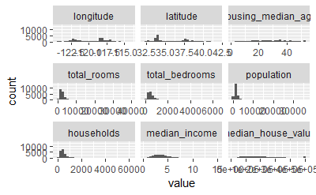

```r
par(mfrow=c(2,5))
ggplot(data = melt(housing), mapping = aes(x = value)) +
    geom_histogram(bins = 30) + facet_wrap(~variable, scales = 'free_x')
```

Now we will clean the data.

Imputing missing values into total_bedrooms.

```r
housing$total_bedrooms[is.na(housing$total_bedrooms)] = median(housing$total_bedrooms , na.rm = TRUE)
```

Making the total columns, mean columns.

```r
housing$mean_bedrooms = housing$total_bedrooms/housing$households
housing$mean_rooms = housing$total_rooms/housing$households
drops = c('total_bedrooms', 'total_rooms')
housing = housing[ , !(names(housing) %in% drops)]
```

Turning the categorical data into boolean columns

```r
categories = unique(housing$ocean_proximity)
cat_housing = data.frame(ocean_proximity = housing$ocean_proximity)
for(cat in categories){
    cat_housing[,cat] = rep(0, times= nrow(cat_housing))
}
for(i in 1:length(cat_housing$ocean_proximity)){
    cat = as.character(cat_housing$ocean_proximity[i])
    cat_housing[,cat][i] = 1
}

cat_columns = names(cat_housing)
keep_columns = cat_columns[cat_columns != 'ocean_proximity']
cat_housing = select(cat_housing,one_of(keep_columns))
```

Our next step is going to be to scale our numerical values to increase accuracy.

```r
drops = c('ocean_proximity','median_house_value')
housing_num =  housing[ , !(names(housing) %in% drops)]
scaled_housing_num = scale(housing_num)
```

Now we will merge the scaled and altered dataframes

```r
cleaned_housing = cbind(cat_housing, scaled_housing_num, median_house_value=housing$median_house_value)
```

Now it is time to train the data. The first step is to create a training environment.

```r
set.seed(1998)
sample = sample.int(n = nrow(cleaned_housing), size = floor(.8*nrow(cleaned_housing)), replace = F)
train = cleaned_housing[sample, ] #just the samples
test  = cleaned_housing[-sample, ]
#everything but the samples
```

```r
library('boot')
glm_house = glm(median_house_value~median_income+mean_rooms+population, data=cleaned_housing)
k_fold_cv_error = cv.glm(cleaned_housing , glm_house, K=5)
k_fold_cv_error$delta
```

```
[1] 6930859971 6929215997
```

```r
glm_cv_rmse = sqrt(k_fold_cv_error$delta)[1]
glm_cv_rmse
```

```
[1] 83251.79
```

The machine learning algorithm we will use is randomforest.

```r
library(randomForest)
set.seed(1738)
train_y = train[,'median_house_value']
train_x = train[, names(train) !='median_house_value']
test_y = test[, 'median_house_value']
test_x = test[, names(test)!= 'median_house_value']
```

```r
rf_model = randomForest(train_x, y = train_y, xtest = test_x, ytest = test_y, ntree = 50, keep.forest = TRUE, importance = TRUE)
```

```r
rf_model$importance
```

```
                      %IncMSE
NEAR BAY            886722574
<1H OCEAN          1111661461
INLAND             4730103509
NEAR OCEAN          422930112
ISLAND                      0
longitude          9376949468
latitude           7234512714
housing_median_age  772091079
population          811150154
households          911961960
median_income      7140241036
mean_bedrooms       393620785
mean_rooms         1748048590
                   IncNodePurity
NEAR BAY            1.392325e+12
<1H OCEAN           1.858975e+12
INLAND              3.248360e+13
NEAR OCEAN          2.513880e+12
ISLAND              2.079421e+10
longitude           3.111849e+13
latitude            2.901368e+13
housing_median_age  8.088787e+12
population          7.164477e+12
households          7.053575e+12
median_income       5.858177e+13
mean_bedrooms       7.061343e+12
mean_rooms          2.644791e+13
```

```r
y_pred = predict(rf_model , test_x)
test_mse = mean(((y_pred - test_y)^2))
test_rmse = sqrt(test_mse)
test_rmse
```

```
[1] 47010.99
```

price of random house = 452,600

```r
random_test <- matrix(c(1,
0,
0,
0,
0,
-1.327803,
1.052523,
0.98211887,
-0.97440499,
-0.977009185,
2.34470896,
-0.148510661,
0.62854423), ncol =13)
random_predict = predict(rf_model, random_test)
```